# R Notebook

```r
library("tidyverse")
library("plotly")
library("imager")
library("here")
```

First step: Run `detect_charuco.ipynb` to detect the points in the videos of the CHaRuCO boards.

Fill in the name of the output CSV file from `detect_charuco.ipynb`.

```r
detections <- read_csv("/Users/Ben/Desktop/Charuco_DLT/charuco_boards/2023_02_09/boards.csv") |>
  select(-`...1`)
```

Fill in the directory that has the video files and the names of each video.

```r
videodir <- '/Users/Ben/Desktop/Charuco_DLT/charuco_boards/2023_02_09'
camfiles <- c('checkerboard_V1.mp4','checkerboard_V2.mp4')
camfiles <- map(camfiles, ~ file.path(videodir, .x))
```

NB: The code below uses `imager`, which won’t load frames properly if there are any spaces in the path name anywhere

Make sure you set the video frame rate correctly.

```r
fps <- 20
```

This will show the 2D locations of each point for one camera.

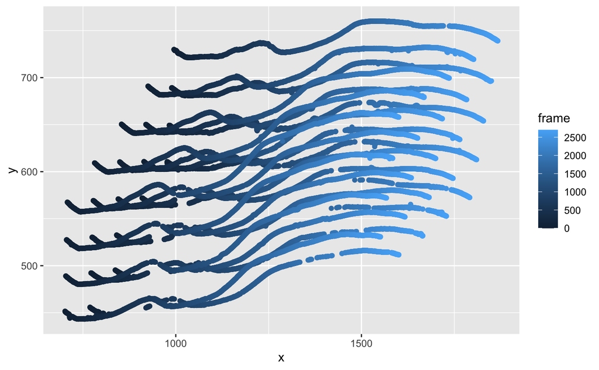

```r
cam <- 2

detections |>
  filter(camera == cam-1) |>
  ggplot(aes(x = x, y = y, color = frame)) +
  geom_point()
```

This shows the range of x and y coordinates in the two cameras, just to check.

```r
detections |>
  group_by(camera) |>
  summarize(fr_hi = max(frame, na.rm = TRUE),
            across(c(x, y),
                   list(lo = ~min(.x, na.rm = TRUE), hi = ~max(.x, na.rm = TRUE))))
```

| camera | fr_hi | x_lo | x_hi | y_lo | y_hi |
| --- | --- | --- | --- | --- | --- |
| 0 | 2700 | 660.2759 | 1685.687 | 408.4573 | 693.7838 |
| 1 | 2700 | 701.7030 | 1867.156 | 443.1270 | 760.1936 |

```r
NA
```

This *should* load in a frame from one of the videos, but it doesn’t always work, and I’m not sure why.

```r
fr <- 10
cam <- 2

vidtime <- (fr-1) / fps

I1 <- imager::load.video(camfiles[[cam]],
                         skip.to = vidtime,
                         frames = 1)
I1 <- as.data.frame(I1)
```

If the above block worked, then you should be able to plot the points and image together here and check to make sure they look OK.

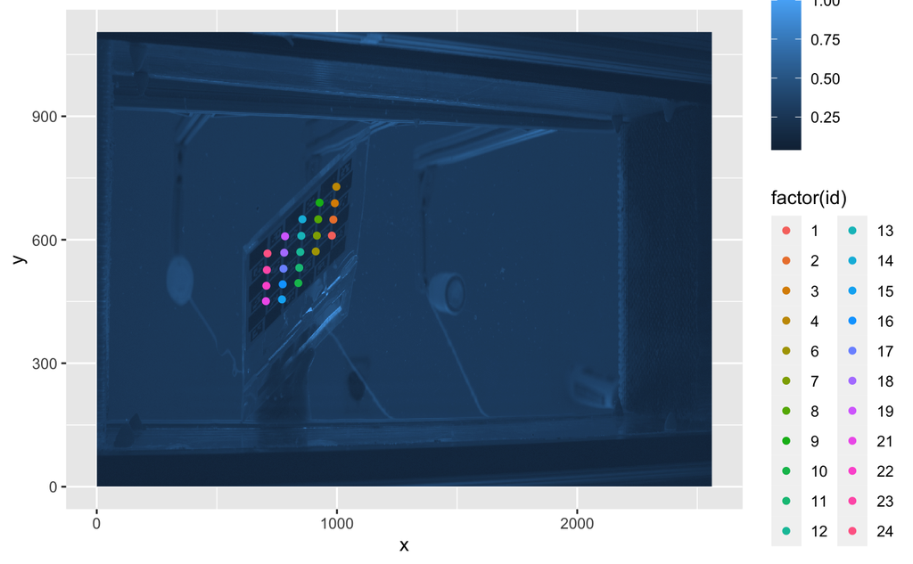

```r
detections |>
  filter(frame == fr-1 & camera == cam-1) |>
  ggplot(aes(x = x, y = y)) +
  geom_raster(data = I1, aes(x = x, y = y, fill = value)) +
  geom_point(aes(color = factor(id)))
```

# Set up points for EasyWand

To rearrange the points for EasyWand, we generate a fake “wand”, which is any pair of points that are separated by the same distance. This takes all of the pairs that are separated by 1 grid square, which generates a *lot* of pairs. Not every computer can process all of those points, so sometimes you want to generate a smaller number. The “wand length” here is 1 grid square (=24.33 mm).

```r
pairs <- list(c(0,1), c(1,2), c(2,3), c(3,4),
              c(5,6), c(6,7), c(7,8), c(8,9),
              c(10,11), c(11,12), c(12,13), c(13,14),
              c(15,16), c(16,17), c(17,18), c(18,19),
              c(20,21), c(21,22), c(22,23), c(23,24),
              c(0,5), c(5,10), c(10,15), c(15,20),
              c(4,9), c(9,14), c(14,19), c(19,24))
```

This just gives the 4 pairs along the 4 edges of the grid. Then the “wand length” is 4 grid squares (=97.32mm).

```r
pairs <- list(c(0,4), c(4,24), c(24,20), c(20,0))
```

Generate all the pairs.

```r
mall <- list()
for (i in seq_along(pairs)) {
  p1 <- pairs[[i]]

  a1 <- detections |> filter(id == p1[1]) |>
    rename(pt1_X = x, pt1_Y = y)
  a2 <- detections |> filter(id == p1[2]) |>
    rename(pt2_X = x, pt2_Y = y)

  if (nrow(a1) > 0 & nrow(a2) > 0) {
    mall[[i]] = left_join(a1, a2, by = c('frame', 'camera')) |>
      unite(id, c('id.x', 'id.y'))
  }
}

m <- bind_rows(mall)
```

Take a look at the beginning of the data frame, just to check.

```r
head(m)
```

| id | pt1_X | pt1_Y | frame | camera | pt2_X | pt2_Y |
| --- | --- | --- | --- | --- | --- | --- |
| 0_4 | 1032.272 | 509.9825 | 365 | 0 | 986.3531 | 640.5538 |
| 0_4 | 1032.658 | 509.6429 | 366 | 0 | 986.5948 | 640.6474 |
| 0_4 | 1032.804 | 509.7897 | 367 | 0 | 986.8588 | 640.7079 |
| 0_4 | 1091.310 | 516.3232 | 575 | 0 | 1049.6335 | 650.6796 |
| 0_4 | 1091.539 | 516.3149 | 576 | 0 | 1049.9920 | 650.6486 |
| 0_4 | 1108.176 | 518.3315 | 633 | 0 | 1068.8962 | 654.3674 |

Finish the reorganization.

```r
ptsforeasywand <-
  m |>
  expand(camera, frame) |>
  left_join(m, by = c('camera', 'frame')) |>
  na.omit() |>
  filter(!str_detect(id, 'NA')) |>
  mutate(camera = camera+1) |>
  pivot_wider(names_from = camera, values_from = starts_with('pt')) |>
  rename_with(~str_replace(.x, '(pt\\d)_([X|Y])_(\\d)', '\\1_cam\\3_\\2')) |>
  select(pt1_cam1_X, pt1_cam1_Y,
         pt1_cam2_X, pt1_cam2_Y,
         pt2_cam1_X, pt2_cam1_Y,
         pt2_cam2_X, pt2_cam2_Y) |>
  na.omit()

head(ptsforeasywand)
```

| pt1_cam1_X | pt1_cam1_Y | pt1_cam2_X | pt1_cam2_Y | pt2_cam1_X | pt2_cam1_Y | pt2_cam2_X | pt2_cam2_Y |
| --- | --- | --- | --- | --- | --- | --- | --- |
| 903.5808 | 638.0689 | 1016.512 | 724.0104 | 660.2759 | 496.2494 | 731.4195 | 559.6531 |
| 909.3148 | 636.7965 | 1023.163 | 722.5400 | 666.2732 | 495.4701 | 738.4089 | 558.1348 |
| 993.3666 | 640.8518 | 1121.092 | 722.9994 | 749.0105 | 502.2107 | 840.0806 | 563.7714 |
| 993.8329 | 641.0040 | 1121.731 | 723.1638 | 749.5959 | 502.0978 | 840.8704 | 564.2289 |
| 994.1896 | 641.0996 | 1122.005 | 723.0917 | 749.7430 | 502.1642 | 841.0914 | 564.0517 |
| 1014.4212 | 645.2717 | 1145.733 | 727.0284 | 769.3414 | 507.1256 | 865.5019 | 569.2280 |

And save out the CSV.

```r
write_csv(ptsforeasywand, "/Users/Ben/Desktop/Charuco_DLT/2023_02_09_calibrationcharuco_xypts.csv")
```

Final step: Load the CSV into EasyWand, punch in the correct fake “wand length”, add the camera parameters (resolution and focal length in pixels; check the SOPs for 3D calibrations for these details for our cameras), and run the calibration.